# Laboratorio_5

2022-11-11

## 1

Importare i dati sulle assicurazioni nel file TL.csv (già usati per Laboratorio 2) e creare una partizione in training e test set a piacere (usare sempre: LFACE = log(FACE) e LINCOME = log(INCOME)).

```r
library(earth)
library(tree)
library(vip)
library(glmnet)
library(leaps)
library(arm)
library(coefplot)

data_TL = read.csv("TL.csv", header = TRUE, colClasses=c("NULL",NA,NA,NA,NA,NA,NA))

data_TL$FACE = log(data_TL$FACE)
data_TL$INCOME = log(data_TL$INCOME)

head(data_TL)
```

```
##   AGE    MARSTAT EDUCATION NUMHH    INCOME      FACE
## 1  30 not single        16     3 10.668955  9.903488
## 2  50 not single         9     3  9.392662 11.775290
## 3  39 not single        16     5 11.695247 14.220976
## 4  43 not single        17     4 10.596635 10.819778
## 5  34 not single        11     4 10.239960 12.301383
## 6  29 not single        16     3 11.512925 13.304685
```

## 2

Stimare un primo albero di regressione usando la funzione tree del medesimo pacchetto. Quali sono le variabili influenti? Quanti sono i nodi terminali? Produrre un grafico dell’albero. Interpretare i risultati e le stime. Confrontare con i risultati lm, ridge e lasso.

```r
set.seed(1234)
dt = sort(sample(nrow(data_TL), nrow(data_TL)*.7))
train = data_TL[dt,]
test = data_TL[-dt,]
```

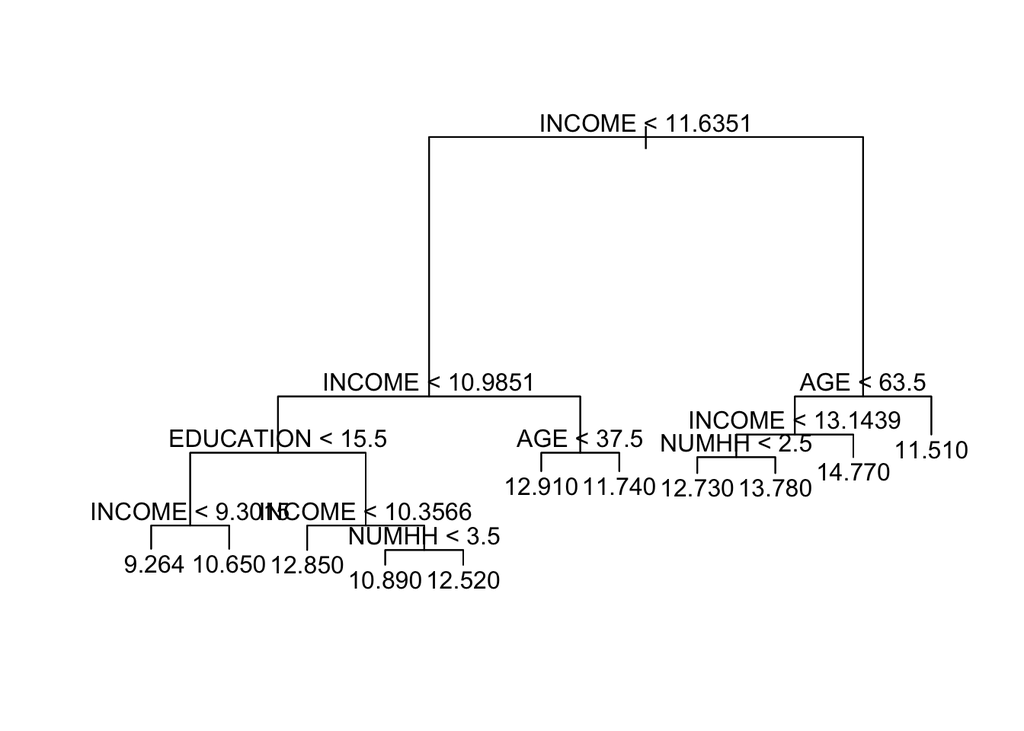

```r
tree_1 = tree(FACE ~ ., data = train)
plot(tree_1)
text(tree_1, pretty = 0)
```

```r
summary(tree_1)
```

```
##
## Regression tree:
## tree(formula = FACE ~ ., data = train)
## Variables actually used in tree construction:
## [1] "INCOME"    "EDUCATION" "NUMHH"     "AGE"
## Number of terminal nodes:  11
## Residual mean deviance:  1.95 = 353 / 181
## Distribution of residuals:
##     Min.  1st Qu.   Median     Mean  3rd Qu.     Max.
## -4.82200 -0.74630  0.01865  0.00000  0.85920  4.37300
```

Nell’albero raffigurato (completo, non potato) sono utilizzate 4 variabili, “INCOME” “EDUCATION” “NUMHH” e “AGE” e sono definiti 11 nodi terminali; si nota come la variabile INCOME sia quella che porti maggiore informazione, viene utilizzato in più nodi e comporta la prima significativa ramificazione.

```r
lm_TL = regsubsets(FACE ~ ., data = data_TL, method = "backward")
summary(lm_TL)
```

```
## Subset selection object
## Call: regsubsets.formula(FACE ~ ., data = data_TL, method = "backward")
## 5 Variables  (and intercept)
##               Forced in Forced out
## AGE               FALSE      FALSE
## MARSTATsingle     FALSE      FALSE
## EDUCATION         FALSE      FALSE
## NUMHH             FALSE      FALSE
## INCOME            FALSE      FALSE
## 1 subsets of each size up to 5
## Selection Algorithm: backward
##          AGE MARSTATsingle EDUCATION NUMHH INCOME
## 1  ( 1 ) " " " "           " "       " "   "*"
## 2  ( 1 ) " " " "           "*"       " "   "*"
## 3  ( 1 ) " " " "           "*"       "*"   "*"
## 4  ( 1 ) " " "*"           "*"       "*"   "*"
## 5  ( 1 ) "*" "*"           "*"       "*"   "*"
```

```r
which.max(summary(lm_TL)$adjr2)
```

```
## [1] 4
```

```r
lm_TL_1 = lm(FACE ~ MARSTAT + EDUCATION + NUMHH + INCOME, data = data_TL)
summary(lm_TL_1)
```

```
##
## Call:
## lm(formula = FACE ~ MARSTAT + EDUCATION + NUMHH + INCOME, data = data_TL)
##
## Residuals:
##     Min      1Q  Median      3Q     Max
## -5.8678 -0.8626  0.1122  0.8384  4.5612
##
## Coefficients:
##               Estimate Std. Error t value Pr(>|t|)
## (Intercept)    3.15499    0.89005   3.545 0.000463 ***
## MARSTATsingle -0.51096    0.25841  -1.977 0.049022 *
## EDUCATION      0.20880    0.03864   5.403 1.44e-07 ***
## NUMHH          0.24749    0.06960   3.556 0.000445 ***
## INCOME         0.46426    0.07854   5.911 1.02e-08 ***
## ---
## Signif. codes:  0 '***' 0.001 '**' 0.01 '*' 0.05 '.' 0.1 ' ' 1
##
## Residual standard error: 1.517 on 270 degrees of freedom
## Multiple R-squared:  0.3519, Adjusted R-squared:  0.3423
## F-statistic: 36.66 on 4 and 270 DF,  p-value: < 2.2e-16
```

LASSO

```r
set.seed(1)
x = model.matrix(FACE ~ ., data_TL)
y = data_TL$FACE
train_1 = sample(1:nrow(x), nrow(x) / 2)
test_1 = (-train_1)
y_test = y[test_1]
```

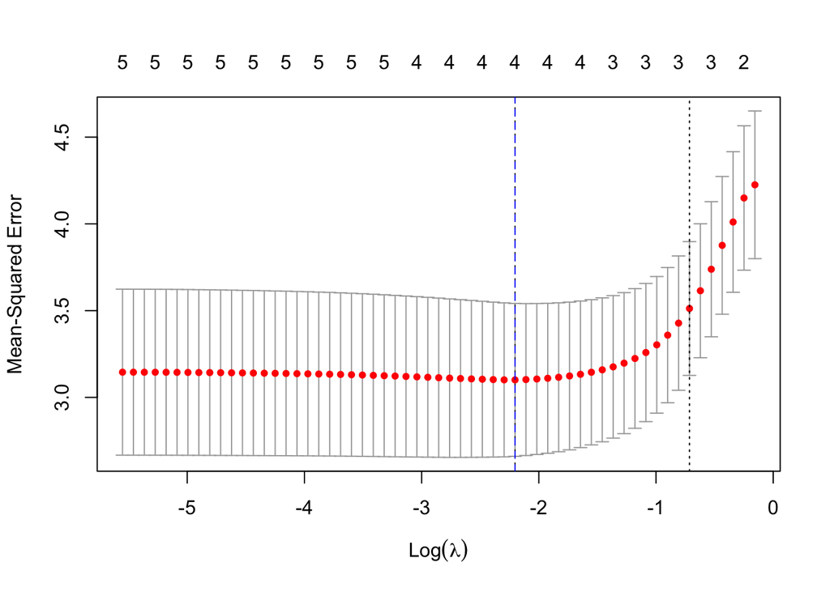

```r
set.seed(1234)
lasso_mod = glmnet(x, y, alpha = 1)
cv_lasso = cv.glmnet(x[train_1, ], y[train_1], alpha = 1)
plot(cv_lasso)
abline(v=log(cv_lasso$lambda.min), col="blue", lty=2)
```

```r
lasso_mdl = glmnet(x, y, alpha=1, lambda=cv_lasso$lambda.min, standardize=TRUE, family="gaussian")
coef(lasso_mdl,s=cv_lasso$lambda.min)
```

```
## 7 x 1 sparse Matrix of class "dgCMatrix"
##                       s1
## (Intercept)    4.2523943
## (Intercept)    .
## AGE            .
## MARSTATsingle -0.3588894
## EDUCATION      0.1698466
## NUMHH          0.1936183
## INCOME         0.4280514
```

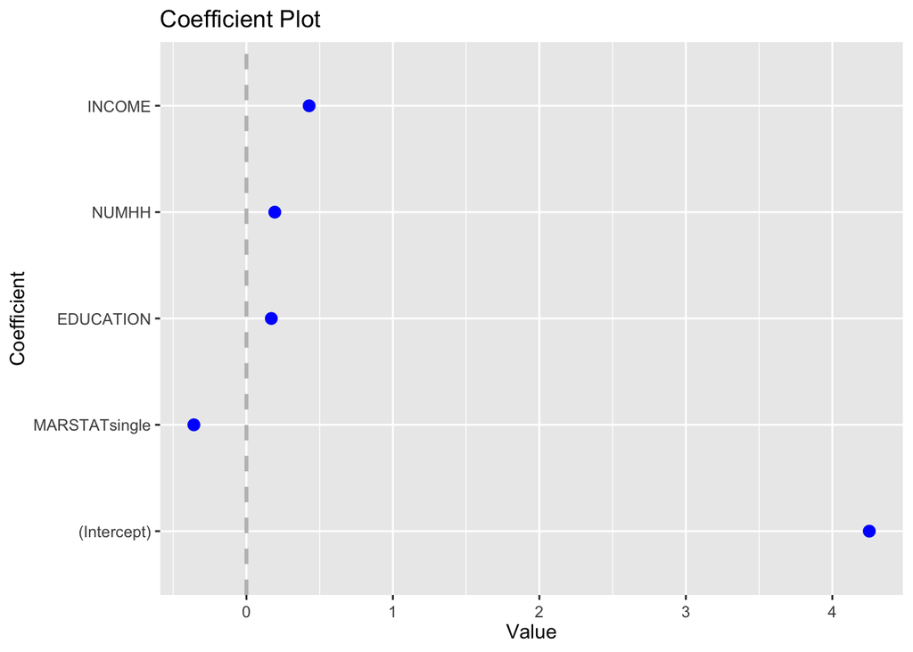

```r
coefplot(lasso_mdl, plot = TRUE)
```

RIDGE

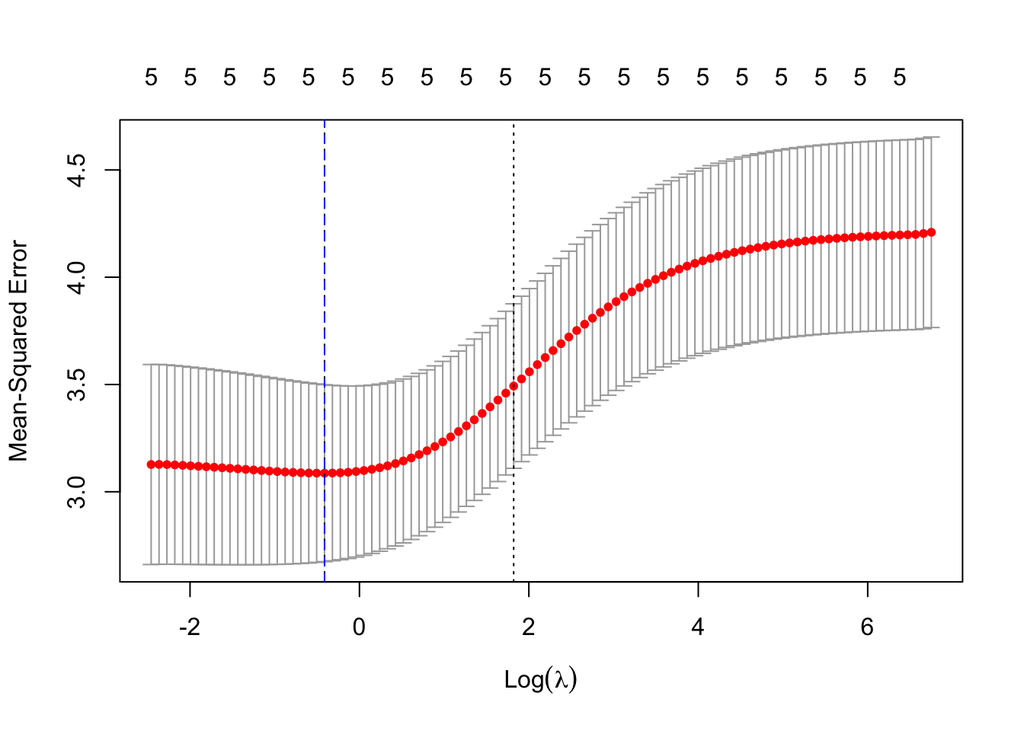

```r
set.seed(1234)
ridge_mod = glmnet(x, y, alpha = 0)
cv_ridge = cv.glmnet(x[train_1, ], y[train_1], alpha = 0)
plot(cv_ridge)
abline(v=log(cv_ridge$lambda.min), col="blue", lty=2)
```

```r
ridge_mdl = glmnet(x, y, alpha=0, lambda=cv_ridge$lambda.min, standardize=TRUE, family="gaussian")
coef(ridge_mdl, s = cv_ridge$lambda.min)
```

```
## 7 x 1 sparse Matrix of class "dgCMatrix"
##                         s1
## (Intercept)    5.148005275
## (Intercept)    .
## AGE           -0.003652953
## MARSTATsingle -0.511340719
## EDUCATION      0.164924503
## NUMHH          0.182253875
## INCOME         0.375656471
```

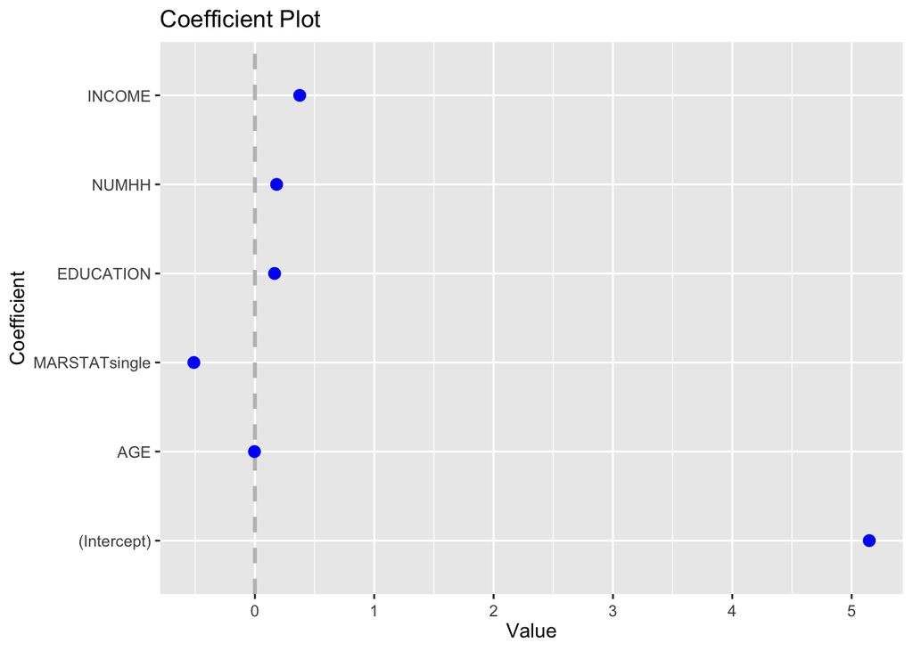

```r
coefplot(ridge_mdl, plot = TRUE)
```

## 3

Ora potare l’albero e calcolare la larghezza ottimale del sotto-albero tramite CV. Produrre un plot per l’albero potato.

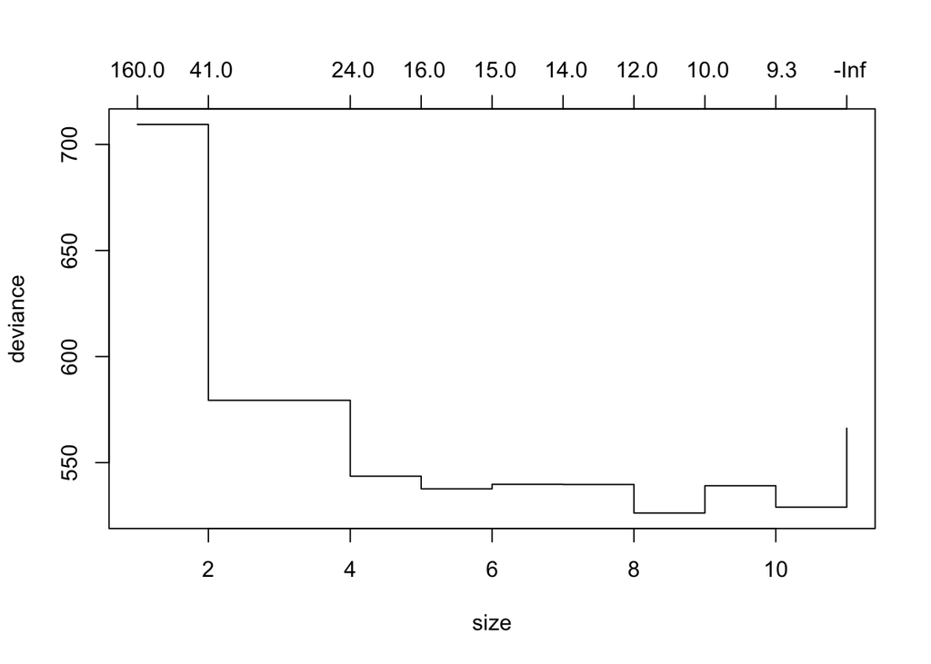

```r
set.seed(1)
tree_1 = tree(FACE ~ ., data = train)
cv_tree1 = cv.tree(tree_1)
plot(cv_tree1)
```

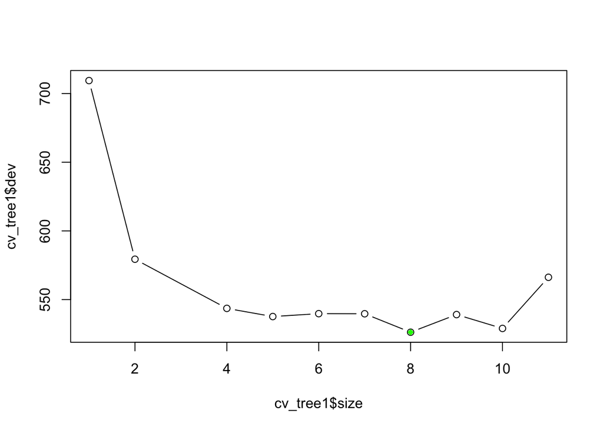

```r
plot(cv_tree1$size, cv_tree1$dev, type = "b")
points(x = 8, y = min(cv_tree1$dev), col='green', pch=18)
```

Trovata la dimensione migliore poto l’albero generale alla data dimensione (8)

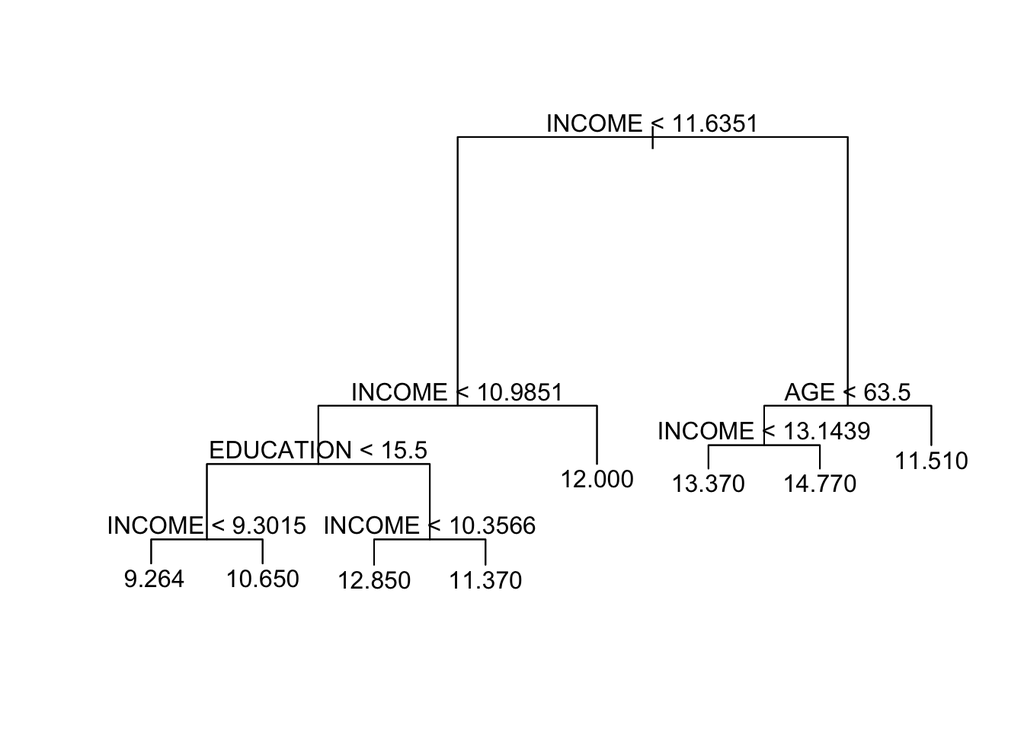

```r
bs_tree = prune.tree(tree_1, best = 8)
plot(bs_tree)
text(bs_tree, pretty = 0)
```

## 4

Ora prevedere e calcolare MSE. Produrre un grafico simile a quello di Figura 8.5 del libro ISL (anche contenuta nella slide 21 della lezione sugli alberi). Commentare i risultati.

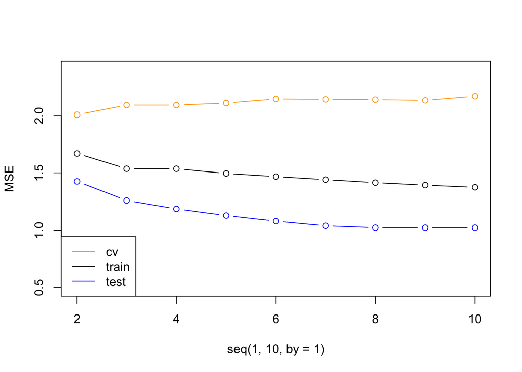

```r
set.seed(1)
tree_train = tree(FACE ~ ., data = train)
mse_train = c()
for (i in 2:10) {
  tree_t = prune.tree(tree_train, best = i)
  pred_t = predict(tree_t, data = train)
    mse_train[i] = sqrt(mean((train$FACE - pred_t)^2))
}

tree_test = tree(FACE ~ ., data = test)
mse_test = c()
for (i in 2:10) {
  tree_t = prune.tree(tree_test, best = i)
  pred_t = predict(tree_t, data = test)
  mse_test[i] = sqrt(mean((test$FACE - pred_t)^2))
}

tree_cv = tree(FACE ~ ., data = train)
mse_cv = c()
for (i in 2:10) {
  tree_t = prune.tree(tree_cv, best = i)
  pred_t = predict(tree_t, data = test)
    mse_cv[i] = sqrt(mean((test$FACE - pred_t)^2))
}

plot(seq(1, 10, by = 1), mse_train, type = "b", ylim = c(0.5, 2.4), xlim = c(2, 10), ylab = "MSE", xlab = )
lines(mse_test, col = "blue", type = "b")
lines(mse_cv, col = "orange", type = "b")
legend(x = "bottomleft", legend = c("cv", "train", "test"), col = c("orange", "black", "blue"),lty = c(1, 1, 1))
```

L’andamento dell’MSE è simile per gli alberi che sono costruiti e calcolati nel medesimo dataset, ovvero quelli denominati train e test: questo fatto è ragionevolmente giustificato dal fatto che gli errori sono calcolati sugli stessi dati su cui gli alberi sono costruiti; a differenza di ciò, gli MSE calcolati mediante cross-validazione sono nettamente più alti in media poiché non sono calcolati sullo stesso dataset che ha generato i dati ma su uno diverso, di test.

Si noti che per i modelli train e test l’MSE cala all’aumentare del numero di nodi fino a stabilizzarsi intorno all’ottavo nodo; per il modello cv rimane pressoché costante.

## 5

Stimare un modello MARS per LFACE, interpretare i risultati e compararli con quelli precedenti (valutare l’inclusione di interazioni mediante argomento degree). Quanti sono i termini totali del modello? Produrre anche un plot sull’importanza delle variabili (analogo a quello di slide 32 della lezione )

```r
mars_1 = earth(FACE ~ ., data = data_TL, nprune = 5, degree = 2)
summary(mars_1)
```

```
## Call: earth(formula=FACE~., data=data_TL, degree=2, nprune=5)
##
##                                     coefficients
## (Intercept)                           10.9174087
## h(EDUCATION-15)                        0.9622036
## h(4-NUMHH)                            -0.4170946
## h(INCOME-10.1266)                      1.1961119
## h(EDUCATION-14) * h(INCOME-10.1266)   -0.2465615
##
## Selected 5 of 19 terms, and 3 of 5 predictors (nprune=5)
## Termination condition: Reached nk 21
## Importance: INCOME, NUMHH, EDUCATION, AGE-unused, MARSTATsingle-unused
## Number of terms at each degree of interaction: 1 3 1
## GCV 2.241474    RSS 568.079    GRSq 0.3618388    RSq 0.4075699
```

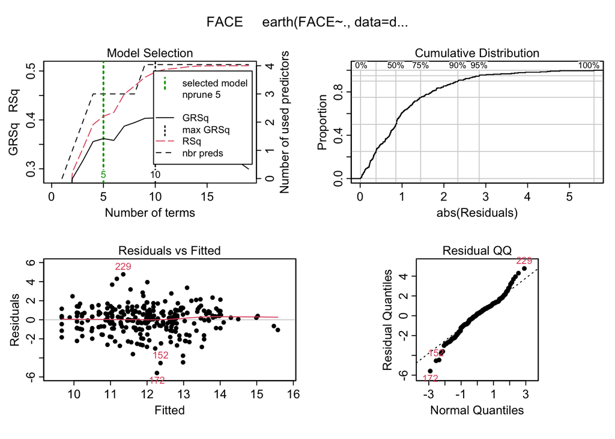

```r
plot(mars_1)
```

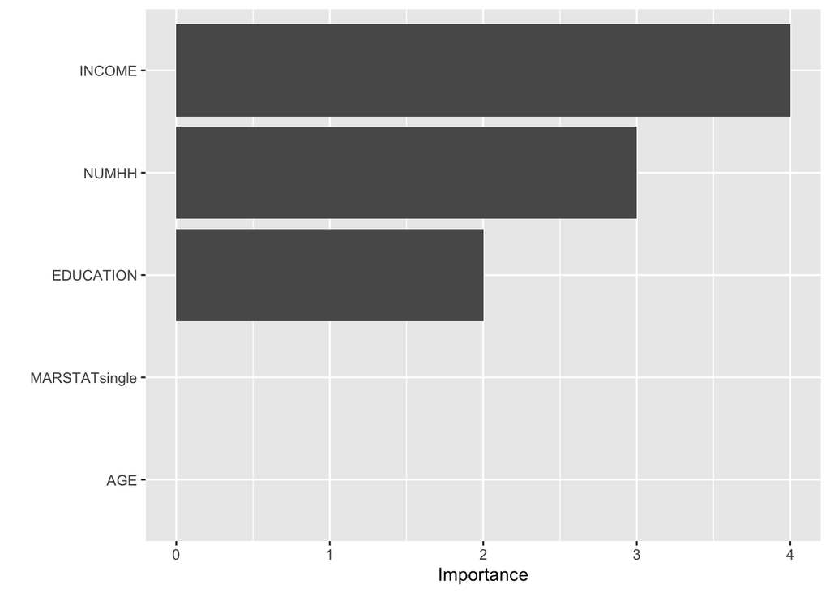

```r
vip(mars_1)
```

```r
set.seed(1)

mars_train = earth(FACE ~ ., data = data_TL, nprune = 5, degree = 2)
mars_cv_1 = c()
for (i in 1:30) {
  mars_tr = earth(FACE ~ ., data = train, nprune = i, degree = 1)
  pred_mars = predict(mars_tr, data = test)
  mars_cv_1[i] = sqrt(mean((train$FACE - pred_mars)^2))
}

mars_cv_2 = c()
for (i in 1:30) {
  mars_tr = earth(FACE ~ ., data = train, nprune = i, degree = 2)
  pred_mars = predict(mars_tr, data = test)
  mars_cv_2[i] = sqrt(mean((train$FACE - pred_mars)^2))
}

mars_cv_3 = c()
for (i in 1:30) {
  mars_tr = earth(FACE ~ ., data = train, nprune = i, degree = 3)
  pred_mars = predict(mars_tr, data = test)
  mars_cv_3[i] = sqrt(mean((train$FACE - pred_mars)^2))
}
```

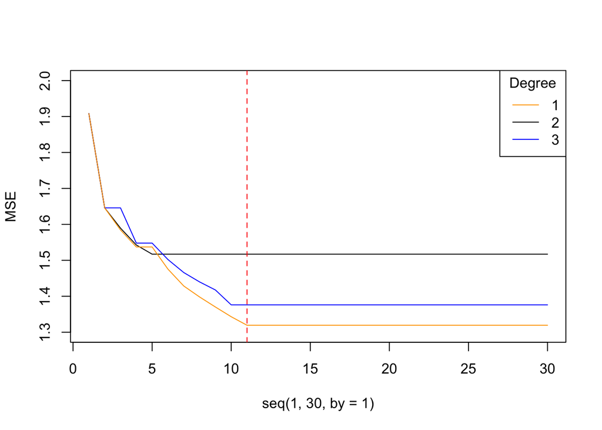

```r
plot(seq(1, 30, by = 1), mars_cv_1, type = "l", xlim = c(1, 30), ylim = c(1.3, 2), ylab = "MSE", xlab = )
lines(mars_cv_2, col = "blue", type = "l")
lines(mars_cv_3, col = "orange", type = "l")
abline(v = 11, col = "red", lty = 2)
legend(x = "topright", legend = c("1", "2", "3"), col = c("orange", "black", "blue"), title = "Degree",lty = c(1, 1, 1))
```

```r
bs_mars = earth(FACE ~ ., data = data_TL, nprune = 11, degree = 3)
summary(bs_mars)
```

```
## Call: earth(formula=FACE~., data=data_TL, degree=3, nprune=11)
##
##                                                 coefficients
## (Intercept)                                       10.7308336
## h(EDUCATION-15)                                    3.9385998
## h(EDUCATION-16)                                   -2.3828968
## h(4-NUMHH)                                        -0.3579439
## h(INCOME-10.1266)                                  1.3623487
## h(AGE-55) * h(EDUCATION-15)                       -0.1044408
## h(EDUCATION-14) * h(INCOME-9.39266)               -0.9652025
## h(EDUCATION-15) * h(INCOME-10.7144)                1.0101456
## h(55-AGE) * h(EDUCATION-15) * h(12.2061-INCOME)   -0.0269349
## h(AGE-55) * h(EDUCATION-15) * h(INCOME-10.9331)    0.0444806
##
## Selected 10 of 19 terms, and 4 of 5 predictors (nprune=11)
## Termination condition: Reached nk 21
## Importance: INCOME, NUMHH, EDUCATION, AGE, MARSTATsingle-unused
## Number of terms at each degree of interaction: 1 4 3 2
## GCV 2.071584    RSS 476.4813    GRSq 0.4102073    RSq 0.503094
```

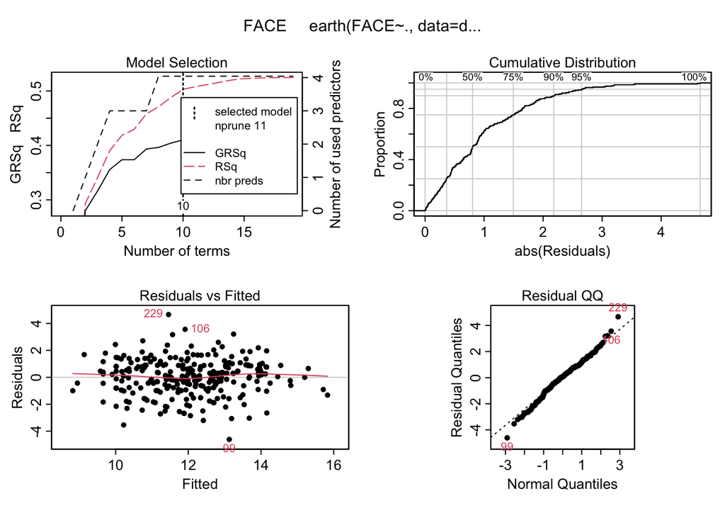

```r
plot(bs_mars)
```

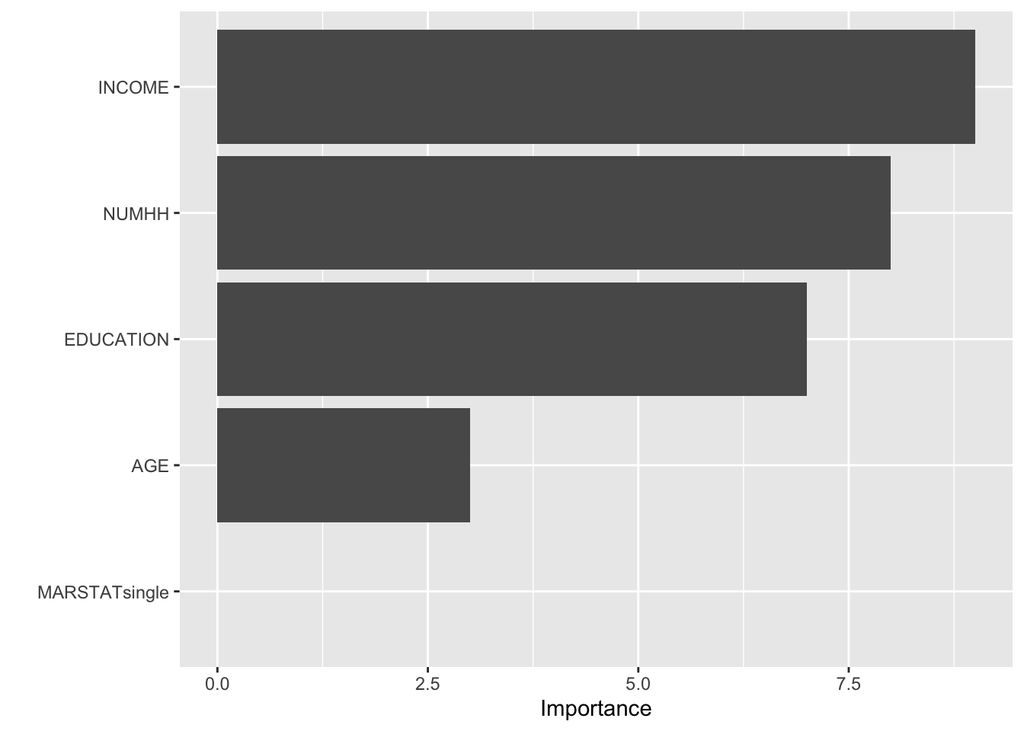

```r
vip(bs_mars)
```

Le variabili utilizzate sono 4: EDUCATION, NUMHH, INCOME e AGE, viene esclusa la variabile MARSTAT; inoltre sono presenti diverse interazioni tra vari livelli delle variabili per un numero totale di 10 coefficienti.

```r
summary(bs_tree)
```

```
##
## Regression tree:
## snip.tree(tree = tree_1, nodes = c(19L, 12L, 5L))
## Variables actually used in tree construction:
## [1] "INCOME"    "EDUCATION" "AGE"
## Number of terminal nodes:  8
## Residual mean deviance:  2.088 = 384.1 / 184
## Distribution of residuals:
##    Min. 1st Qu.  Median    Mean 3rd Qu.    Max.
## -4.8510 -0.7479  0.0967  0.0000  0.8592  4.1170
```

```r
summary(bs_mars)
```

```
## Call: earth(formula=FACE~., data=data_TL, degree=3, nprune=11)
##
##                                                 coefficients
## (Intercept)                                       10.7308336
## h(EDUCATION-15)                                    3.9385998
## h(EDUCATION-16)                                   -2.3828968
## h(4-NUMHH)                                        -0.3579439
## h(INCOME-10.1266)                                  1.3623487
## h(AGE-55) * h(EDUCATION-15)                       -0.1044408
## h(EDUCATION-14) * h(INCOME-9.39266)               -0.9652025
## h(EDUCATION-15) * h(INCOME-10.7144)                1.0101456
## h(55-AGE) * h(EDUCATION-15) * h(12.2061-INCOME)   -0.0269349
## h(AGE-55) * h(EDUCATION-15) * h(INCOME-10.9331)    0.0444806
##
## Selected 10 of 19 terms, and 4 of 5 predictors (nprune=11)
## Termination condition: Reached nk 21
## Importance: INCOME, NUMHH, EDUCATION, AGE, MARSTATsingle-unused
## Number of terms at each degree of interaction: 1 4 3 2
## GCV 2.071584    RSS 476.4813    GRSq 0.4102073    RSq 0.503094
```

```r
summary(ridge_mdl)
```

```
##           Length Class     Mode
## a0        1      -none-    numeric
## beta      6      dgCMatrix S4
## df        1      -none-    numeric
## dim       2      -none-    numeric
## lambda    1      -none-    numeric
## dev.ratio 1      -none-    numeric
## nulldev   1      -none-    numeric
## npasses   1      -none-    numeric
## jerr      1      -none-    numeric
## offset    1      -none-    logical
## call      7      -none-    call
## nobs      1      -none-    numeric
```

```r
summary(lasso_mdl)
```

```
##           Length Class     Mode
## a0        1      -none-    numeric
## beta      6      dgCMatrix S4
## df        1      -none-    numeric
## dim       2      -none-    numeric
## lambda    1      -none-    numeric
## dev.ratio 1      -none-    numeric
## nulldev   1      -none-    numeric
## npasses   1      -none-    numeric
## jerr      1      -none-    numeric
## offset    1      -none-    logical
## call      7      -none-    call
## nobs      1      -none-    numeric
```